# Prediction of Term Deposit Subscription

```r
rm(list = ls(all=TRUE))
```

# Agenda

- Get the data
- Data Pre-processing
- Build a model
- Predictions
- Communication

# Reading & Understanding the Data

```r
bank_data <- read.table("bank.txt", header=T, sep=";")
```

## Data Description

- The dataset is from a bank, using which we have to predict whether the subject subscribes to a term deposit or not
- The dataset has the following attributes:

1 - age (numeric)

2 - job : type of job (categorical: “admin.”,“unknown”,“unemployed”,“management”,“housemaid”,“entrepreneur”,“student”, “blue-collar”,“self-employed”,“retired”,“technician”,“services”)

3 - marital : marital status (categorical: “married”,“divorced”,“single”; note: “divorced” means divorced or widowed)

4 - education (categorical: “unknown”,“secondary”,“primary”,“tertiary”)

5 - default: has credit in default? (binary: “yes”,“no”)

6 - balance: average yearly balance, in euros (numeric)

7 - housing: has housing loan? (binary: “yes”,“no”)

8 - loan: has personal loan? (binary: “yes”,“no”)

9 - contact: contact communication type (categorical: “unknown”,“telephone”,“cellular”)

10 - day: last contact day of the month (numeric)

11 - month: last contact month of year (categorical: “jan”, “feb”, “mar”, …, “nov”, “dec”)

12 - duration: last contact duration, in seconds (numeric)

13 - campaign: number of contacts performed during this campaign and for this client (numeric, includes last contact)

14 - pdays: number of days that passed by after the client was last contacted from a previous campaign (numeric, -1 means client was not previously contacted)

15 - previous: number of contacts performed before this campaign and for this client (numeric)

16 - poutcome: outcome of the previous marketing campaign (categorical: “unknown”,“other”,“failure”,“success”)

**Response Variable (desired target):**

17 - y - has the client subscribed to a **term deposit?** (binary: “yes”,“no”)

## Understand the data

- The dataset has 4521 observations and 17 variables

```r
str(bank_data)
```

```
## 'data.frame':    4521 obs. of  17 variables:
##  $ age      : int  30 33 35 30 59 35 36 39 41 43 ...
##  $ job      : Factor w/ 12 levels "admin.","blue-collar",..: 11 8 5 5 2 5 7 10 3 8 ...
##  $ marital  : Factor w/ 3 levels "divorced","married",..: 2 2 3 2 2 3 2 2 2 2 ...
##  $ education: Factor w/ 4 levels "primary","secondary",..: 1 2 3 3 2 3 3 2 3 1 ...
##  $ default  : Factor w/ 2 levels "no","yes": 1 1 1 1 1 1 1 1 1 1 ...
##  $ balance  : int  1787 4789 1350 1476 0 747 307 147 221 -88 ...
##  $ housing  : Factor w/ 2 levels "no","yes": 1 2 2 2 2 1 2 2 2 2 ...
##  $ loan     : Factor w/ 2 levels "no","yes": 1 2 1 2 1 1 1 1 1 2 ...
##  $ contact  : Factor w/ 3 levels "cellular","telephone",..: 1 1 1 3 3 1 1 1 3 1 ...
##  $ day      : int  19 11 16 3 5 23 14 6 14 17 ...
##  $ month    : Factor w/ 12 levels "apr","aug","dec",..: 11 9 1 7 9 4 9 9 9 1 ...
##  $ duration : int  79 220 185 199 226 141 341 151 57 313 ...
##  $ campaign : int  1 1 1 4 1 2 1 2 2 1 ...
##  $ pdays    : int  -1 339 330 -1 -1 176 330 -1 -1 147 ...
##  $ previous : int  0 4 1 0 0 3 2 0 0 2 ...
##  $ poutcome : Factor w/ 4 levels "failure","other",..: 4 1 1 4 4 1 2 4 4 1 ...
##  $ y        : Factor w/ 2 levels "no","yes": 1 1 1 1 1 1 1 1 1 1 ...
```

- Use the summary() function to understand the distribution of variables in the dataset

```r
summary(bank_data)
```

```
##       age                 job          marital         education
##  Min.   :19.00   management :969   divorced: 528   primary  : 678
##  1st Qu.:33.00   blue-collar:946   married :2797   secondary:2306
##  Median :39.00   technician :768   single  :1196   tertiary :1350
##  Mean   :41.17   admin.     :478                   unknown  : 187
##  3rd Qu.:49.00   services   :417
##  Max.   :87.00   retired    :230
##                  (Other)    :713
##  default       balance      housing     loan           contact
##  no :4445   Min.   :-3313   no :1962   no :3830   cellular :2896
##  yes:  76   1st Qu.:   69   yes:2559   yes: 691   telephone: 301
##             Median :  444                         unknown  :1324
##             Mean   : 1423
##             3rd Qu.: 1480
##             Max.   :71188
##
##       day            month         duration       campaign
##  Min.   : 1.00   may    :1398   Min.   :   4   Min.   : 1.000
##  1st Qu.: 9.00   jul    : 706   1st Qu.: 104   1st Qu.: 1.000
##  Median :16.00   aug    : 633   Median : 185   Median : 2.000
##  Mean   :15.92   jun    : 531   Mean   : 264   Mean   : 2.794
##  3rd Qu.:21.00   nov    : 389   3rd Qu.: 329   3rd Qu.: 3.000
##  Max.   :31.00   apr    : 293   Max.   :3025   Max.   :50.000
##                  (Other): 571
##      pdays           previous          poutcome      y
##  Min.   : -1.00   Min.   : 0.0000   failure: 490   no :4000
##  1st Qu.: -1.00   1st Qu.: 0.0000   other  : 197   yes: 521
##  Median : -1.00   Median : 0.0000   success: 129
##  Mean   : 39.77   Mean   : 0.5426   unknown:3705
##  3rd Qu.: -1.00   3rd Qu.: 0.0000
##  Max.   :871.00   Max.   :25.0000
##
```

```r
head(bank_data)
```

```
##   age         job marital education default balance housing loan  contact
## 1  30  unemployed married   primary      no    1787      no   no cellular
## 2  33    services married secondary      no    4789     yes  yes cellular
## 3  35  management  single  tertiary      no    1350     yes   no cellular
## 4  30  management married  tertiary      no    1476     yes  yes  unknown
## 5  59 blue-collar married secondary      no       0     yes   no  unknown
## 6  35  management  single  tertiary      no     747      no   no cellular
##   day month duration campaign pdays previous poutcome  y
## 1  19   oct       79        1    -1        0  unknown no
## 2  11   may      220        1   339        4  failure no
## 3  16   apr      185        1   330        1  failure no
## 4   3   jun      199        4    -1        0  unknown no
## 5   5   may      226        1    -1        0  unknown no
## 6  23   feb      141        2   176        3  failure no
```

```r
tail(bank_data)
```

```
##      age           job marital education default balance housing loan
## 4516  32      services  single secondary      no     473     yes   no
## 4517  33      services married secondary      no    -333     yes   no
## 4518  57 self-employed married  tertiary     yes   -3313     yes  yes
## 4519  57    technician married secondary      no     295      no   no
## 4520  28   blue-collar married secondary      no    1137      no   no
## 4521  44  entrepreneur  single  tertiary      no    1136     yes  yes
##       contact day month duration campaign pdays previous poutcome  y
## 4516 cellular   7   jul      624        5    -1        0  unknown no
## 4517 cellular  30   jul      329        5    -1        0  unknown no
## 4518  unknown   9   may      153        1    -1        0  unknown no
## 4519 cellular  19   aug      151       11    -1        0  unknown no
## 4520 cellular   6   feb      129        4   211        3    other no
## 4521 cellular   3   apr      345        2   249        7    other no
```

# Data Pre-processing

## Missing Values

- Missing Data

```r
sum(is.na(bank_data))
```

```
## [1] 0
```

## Train/Test Split

```r
library(caret)
set.seed(123)

train_rows <- createDataPartition(bank_data$y, p = 0.7, list = F)

train_data <- bank_data[train_rows, ]

test_data <- bank_data[-train_rows, ]
```

```r
str(train_data)
```

```
## 'data.frame':    3165 obs. of  17 variables:
##  $ age      : int  30 33 30 59 36 39 41 43 39 43 ...
##  $ job      : Factor w/ 12 levels "admin.","blue-collar",..: 11 8 5 2 7 10 3 8 8 1 ...
##  $ marital  : Factor w/ 3 levels "divorced","married",..: 2 2 2 2 2 2 2 2 2 2 ...
##  $ education: Factor w/ 4 levels "primary","secondary",..: 1 2 3 2 3 2 3 1 2 2 ...
##  $ default  : Factor w/ 2 levels "no","yes": 1 1 1 1 1 1 1 1 1 1 ...
##  $ balance  : int  1787 4789 1476 0 307 147 221 -88 9374 264 ...
##  $ housing  : Factor w/ 2 levels "no","yes": 1 2 2 2 2 2 2 2 2 2 ...
##  $ loan     : Factor w/ 2 levels "no","yes": 1 2 2 1 1 1 1 2 1 1 ...
##  $ contact  : Factor w/ 3 levels "cellular","telephone",..: 1 1 3 3 1 1 3 1 3 1 ...
##  $ day      : int  19 11 3 5 14 6 14 17 20 17 ...
##  $ month    : Factor w/ 12 levels "apr","aug","dec",..: 11 9 7 9 9 9 9 1 9 1 ...
##  $ duration : int  79 220 199 226 341 151 57 313 273 113 ...
##  $ campaign : int  1 1 4 1 1 2 2 1 1 2 ...
##  $ pdays    : int  -1 339 -1 -1 330 -1 -1 147 -1 -1 ...
##  $ previous : int  0 4 0 0 2 0 0 2 0 0 ...
##  $ poutcome : Factor w/ 4 levels "failure","other",..: 4 1 4 4 2 4 4 1 4 4 ...
##  $ y        : Factor w/ 2 levels "no","yes": 1 1 1 1 1 1 1 1 1 1 ...
```

# Build a model

## Basic Logistic Regression Model

```r
log_reg <- glm(y~., data = train_data, family = binomial)
```

- Summary

```r
summary(log_reg)
```

```
##
## Call:
## glm(formula = y ~ ., family = binomial, data = train_data)
##
## Deviance Residuals:
##     Min       1Q   Median       3Q      Max
## -4.1937  -0.3720  -0.2489  -0.1538   3.0719
##
## Coefficients:
##                      Estimate Std. Error z value Pr(>|z|)
## (Intercept)        -3.599e+00  7.486e-01  -4.807 1.53e-06 ***
## age                -3.587e-03  8.601e-03  -0.417 0.676704
## jobblue-collar     -3.232e-01  2.950e-01  -1.095 0.273366
## jobentrepreneur    -6.579e-01  5.137e-01  -1.281 0.200308
## jobhousemaid       -1.890e-01  4.953e-01  -0.381 0.702845
## jobmanagement      -1.336e-01  2.935e-01  -0.455 0.649018
## jobretired          6.680e-01  3.797e-01   1.759 0.078511 .
## jobself-employed   -2.870e-01  4.441e-01  -0.646 0.518019
## jobservices        -2.415e-01  3.445e-01  -0.701 0.483236
## jobstudent          1.563e-02  4.912e-01   0.032 0.974617
## jobtechnician      -1.647e-01  2.830e-01  -0.582 0.560592
## jobunemployed      -4.001e-01  4.738e-01  -0.844 0.398455
## jobunknown          6.392e-01  6.380e-01   1.002 0.316399
## maritalmarried     -1.247e-01  2.217e-01  -0.562 0.573779
## maritalsingle      -1.369e-01  2.599e-01  -0.527 0.598339
## educationsecondary -1.374e-02  2.396e-01  -0.057 0.954281
## educationtertiary   4.146e-01  2.745e-01   1.510 0.131003
## educationunknown   -4.946e-01  4.283e-01  -1.155 0.248119
## defaultyes          7.424e-01  5.179e-01   1.433 0.151725
## balance            -1.139e-05  2.101e-05  -0.542 0.587774
## housingyes         -2.569e-01  1.665e-01  -1.543 0.122835
## loanyes            -5.712e-01  2.412e-01  -2.368 0.017889 *
## contacttelephone   -9.117e-02  2.750e-01  -0.331 0.740279
## contactunknown     -1.623e+00  2.767e-01  -5.865 4.49e-09 ***
## day                 1.948e-02  9.998e-03   1.948 0.051361 .
## monthaug           -3.709e-01  3.049e-01  -1.217 0.223706
## monthdec           -1.679e-01  9.261e-01  -0.181 0.856114
## monthfeb            2.801e-01  3.584e-01   0.782 0.434390
## monthjan           -1.372e+00  4.825e-01  -2.844 0.004451 **
## monthjul           -7.924e-01  3.068e-01  -2.583 0.009800 **
```

[output cut: 8 more lines]

```
## pdays               1.865e-03  1.188e-03   1.569 0.116587
## previous           -1.893e-02  4.585e-02  -0.413 0.679635
## poutcomeother       7.400e-01  3.357e-01   2.205 0.027486 *
## poutcomesuccess     2.876e+00  3.469e-01   8.291  < 2e-16 ***
## poutcomeunknown     6.673e-01  4.100e-01   1.628 0.103623
## ---
## Signif. codes:  0 '***' 0.001 '**' 0.01 '*' 0.05 '.' 0.1 ' ' 1
##
## (Dispersion parameter for binomial family taken to be 1)
##
##     Null deviance: 2263.0  on 3164  degrees of freedom
## Residual deviance: 1498.5  on 3122  degrees of freedom
## AIC: 1584.5
##
## Number of Fisher Scoring iterations: 6
```

# ROC

## Predicted Values are between 0 and 1

- The predict() function on the “glm” object of “binomial” family gives a probability score between 0 and 1, NOT the original levels (0 and 1) of the response variable
- Hence we must first choose a cutoff point for getting to the original levels of the response variables
- To choose the cutoff point we will use the train data, as test data should not be used to make any decisions regarding the model

## Creating an ROC plot

```r
prob_train <- predict(log_reg, type = "response")

library(ROCR)
pred <- prediction(prob_train, train_data$y)
```

```r
perf <- performance(pred, measure="tpr", x.measure="fpr")
```

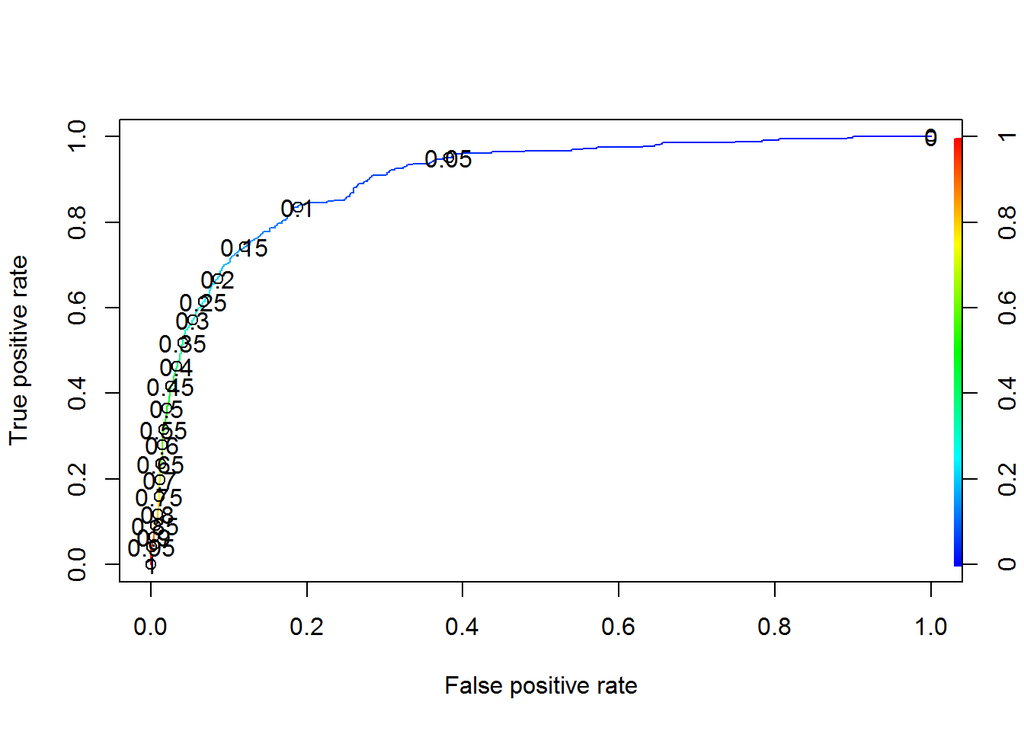

```r
plot(perf, col=rainbow(10), colorize=T, print.cutoffs.at=seq(0,1,0.05))
```

- Extract the AUC score of the ROC curve and store it in a variable named “auc”

```r
perf_auc <- performance(pred, measure="auc")

# Access the auc score from the performance object

auc <- perf_auc@y.values[[1]]

print(auc)
```

```
## [1] 0.8985499
```

## Choose a Cutoff Value

- Based on the trade off between TPR and FPR depending on the business domain, a call on the cutoff has to be made.

## Predictions on test data

- After choosing a cutoff value of 0.1, let’s predict the class labels on the test data using our model

```r
prob_test <- predict(log_reg, test_data, type = "response")

preds_test <- ifelse(prob_test > 0.1, "yes", "no")
```

# Evaluation Metrics for classification

### Confusion Matrix

- Create a confusion matrix using the table() function

```r
test_data_labs <- test_data$y

conf_matrix <- table(test_data_labs, preds_test)

print(conf_matrix)
```

```
##               preds_test
## test_data_labs  no yes
##            no  986 214
##            yes  24 132
```

### Specificity

- The Proportion of correctly identified negatives by the test/model.

$${Specificity} = \frac{Number~of~True~Negatives}{Number~of~True~Negatives + Number~of~False~Positives}$$

```r
specificity <- conf_matrix[1, 1]/sum(conf_matrix[1, ])

print(specificity)
```

```
## [1] 0.8216667
```

### Sensitivity

- The Proportion of correctly identified positives by the test/model.

$${Sensitivity} = \frac{Number~of~True~Positives}{Number~of~True~Positives + Number~of~False~Negatives}$$

```r
sensitivity <- conf_matrix[2, 2]/sum(conf_matrix[2, ])

print(sensitivity)
```

```
## [1] 0.8461538
```

### Accuracy

- The Proportion of correctly identified psotivies/negatives in the entire population by the test/model

$${Accuracy} = \frac{Number~of~True~Positives +Number~of~True~Negatives}{Number~Of~Subjects~in~the~Population}$$

```r
accuracy <- sum(diag(conf_matrix))/sum(conf_matrix)

print(accuracy)
```

```
## [1] 0.8244838
```

## Automated Computation

```r
library(caret)
confusionMatrix(as.factor(preds_test), as.factor(test_data$y), positive = "yes")
```

```
## Confusion Matrix and Statistics
##
##           Reference
## Prediction  no yes
##        no  986  24
##        yes 214 132
##
##                Accuracy : 0.8245
##                  95% CI : (0.8032, 0.8444)
##     No Information Rate : 0.885
##     P-Value [Acc > NIR] : 1
##
##                   Kappa : 0.4365
##
##  Mcnemar's Test P-Value : <2e-16
##
##             Sensitivity : 0.84615
##             Specificity : 0.82167
##          Pos Pred Value : 0.38150
##          Neg Pred Value : 0.97624
##              Prevalence : 0.11504
##          Detection Rate : 0.09735
##    Detection Prevalence : 0.25516
##       Balanced Accuracy : 0.83391
##
##        'Positive' Class : yes
##
```